# K modas & K prototipos

Brenda Georgina Tafoya Olvera

24/4/2020

### K modas

El algoritmo k-modas (Zhexue., 1998), fue diseñado para agrupar conjuntos de datos categóricos, y tiene como objetivo obtener las k modas que representan al conjunto.

En k-modas se hacen 3 modificaciones a k-medias:

- Uso de **diferentes medidas de disimililitud** (dissimilarity). Sean X, Y dos objetos categóricos descritos por m atributos categóricos. La la medida de disimilitud entre X e Y puede definirse por las **discrepancias (missmatches) totales de los atributos categóricos de los objetos.** Cuanto menor es este número, más similares son los dos objetos.

  Formalmente, se escribe así,
  $$d(X,Y)= \sum_{j=1}^{m}\delta (X_{j}, Y_{j})$$
  donde,
  $$\delta (X_{j}, Y_{j}) = \begin{cases}
  0 & \text{ if } x_{j} = y_{j} \\
  1 & \text{ if } x_{j} \neq y_{j}
  \end{cases}$$
- Está basado en las **frecuencias de los datos para actualizar las modas**. $d(X,Y)$ da igual importancia a cada categoría del atributo. Tomando en cuenta las frecuencias de las categorías en el conjunto de datos, se define la medida de disimilaridad,
  $$d_{2}(X,Y)= \sum_{j=1}^{m}\frac{{n_{xj}}+{n_{yj}}}{{n_{xj}}{n_{yj}}}*\delta (X_{j}, Y_{j})$$
  Dónde, $nxj$ $nyj$ son el número de objetos en el conjunto de datos, que tienen las categorías xj y yj para el atributo j. A esta medida de disimilitud se le conoce como distancia Xi-cuadrada.
- Sustitución de k medias por **k modas para formar los centroides**. La *moda* es un vector de elementos $Q=[q_{1}, q_{2}, ..., q_{m}]\in \Omega$ que minimiza las diferencias (dissimilarities) entre el vector en sí y cada objeto de los datos.
  $$D(X,Q)= \sum_{j=1}^{n}d (X_{j}, Q)$$

Similar al algoritmo k-medias, el objetivo de agrupar el conjunto X es encontrar un conjunto ${ Q_{1}, Q_{2}, ..., Q_{m} }$ que minimice la función de costo total

### Algortimo

1. Seleccionar k modas iniciales, una para cada grupo.
2. Asignar cada objeto a la moda más cercana utilizando la distancia d. Actualizar la moda del grupo después de cada asignación.
3. Después que todos los objetos han sido asignados a un grupo, volver a examinar la disimilaridad de los objetos con las modas actuales. Si un objeto es encontrado tal que su moda más cercana corresponde a otro grupo, asignar el objeto a su nueva moda y actualizar la moda de ambos grupos.
4. Repetir el paso 3 hasta que no existan objetos cambiados de grupo

*observaciones:*

- En el caso de k modas, la actualización de las modas se realiza en cada asignación de un objeto a su grupo, mientras que en k-medias es al final de cada iteración del algoritmo.
- El algoritmo k-modas al igual que el algoritmo k-medias produce soluciones óptimas locales, que dependen del conjunto de modas iniciales y el orden de los objetos en el conjunto de datos.

### Implementación en R

Pimero, es necesaria la instalación del paquete de [klaR](https://cran.r-project.org/web/packages/klaR/index.html)

```r
install.packages("klaR")
```

Usaremos la función de kmodes, que tiene la misma estructura que la función *kmeans*

```r
kmodes(data, modes, iter.max = 10, weighted = FALSE)
```

- **data**: A matrix or data frame of categorical data. Objects have to be in rows, variables in columns.
- **modes**: Either the number of modes or a set of initial (distinct) cluster modes. If a number, a random set of (distinct) rows in data is chosen as the initial modes.
- **iter.max**: The maximum number of iterations allowed.
- **weighted**: Whether usual simple-matching distance between objects is used, or a weighted version of this distance (by the frequencies of the categories in data)

#### Ejemplo

Como ejemplo queremos clasificar distintos tipos de hongos, el dataset es *[Mushroom Classification Dataset](https://www.kaggle.com/uciml/mushroom-classification)*

```r
library(klaR)
```

```r
library(ggplot2)
library(dplyr)
mushroomDf <- read.csv("C:/Users/ginat/Desktop/mushrooms.csv")
str( mushroomDf )
```

```
## 'data.frame':    8124 obs. of  23 variables:
##  $ class                   : Factor w/ 2 levels "e","p": 2 1 1 2 1 1 1 1 2 1 ...
##  $ cap.shape               : Factor w/ 6 levels "b","c","f","k",..: 6 6 1 6 6 6 1 1 6 1 ...
##  $ cap.surface             : Factor w/ 4 levels "f","g","s","y": 3 3 3 4 3 4 3 4 4 3 ...
##  $ cap.color               : Factor w/ 10 levels "b","c","e","g",..: 5 10 9 9 4 10 9 9 9 10 ...
##  $ bruises                 : Factor w/ 2 levels "f","t": 2 2 2 2 1 2 2 2 2 2 ...
##  $ odor                    : Factor w/ 9 levels "a","c","f","l",..: 7 1 4 7 6 1 1 4 7 1 ...
##  $ gill.attachment         : Factor w/ 2 levels "a","f": 2 2 2 2 2 2 2 2 2 2 ...
##  $ gill.spacing            : Factor w/ 2 levels "c","w": 1 1 1 1 2 1 1 1 1 1 ...
##  $ gill.size               : Factor w/ 2 levels "b","n": 2 1 1 2 1 1 1 1 2 1 ...
##  $ gill.color              : Factor w/ 12 levels "b","e","g","h",..: 5 5 6 6 5 6 3 6 8 3 ...
##  $ stalk.shape             : Factor w/ 2 levels "e","t": 1 1 1 1 2 1 1 1 1 1 ...
##  $ stalk.root              : Factor w/ 5 levels "?","b","c","e",..: 4 3 3 4 4 3 3 3 4 3 ...
##  $ stalk.surface.above.ring: Factor w/ 4 levels "f","k","s","y": 3 3 3 3 3 3 3 3 3 3 ...
##  $ stalk.surface.below.ring: Factor w/ 4 levels "f","k","s","y": 3 3 3 3 3 3 3 3 3 3 ...
##  $ stalk.color.above.ring  : Factor w/ 9 levels "b","c","e","g",..: 8 8 8 8 8 8 8 8 8 8 ...
##  $ stalk.color.below.ring  : Factor w/ 9 levels "b","c","e","g",..: 8 8 8 8 8 8 8 8 8 8 ...
##  $ veil.type               : Factor w/ 1 level "p": 1 1 1 1 1 1 1 1 1 1 ...
##  $ veil.color              : Factor w/ 4 levels "n","o","w","y": 3 3 3 3 3 3 3 3 3 3 ...
##  $ ring.number             : Factor w/ 3 levels "n","o","t": 2 2 2 2 2 2 2 2 2 2 ...
##  $ ring.type               : Factor w/ 5 levels "e","f","l","n",..: 5 5 5 5 1 5 5 5 5 5 ...
##  $ spore.print.color       : Factor w/ 9 levels "b","h","k","n",..: 3 4 4 3 4 3 3 4 3 3 ...
##  $ population              : Factor w/ 6 levels "a","c","n","s",..: 4 3 3 4 1 3 3 4 5 4 ...
##  $ habitat                 : Factor w/ 7 levels "d","g","l","m",..: 6 2 4 6 2 2 4 4 2 4 ...
```

```r
#Quitamos las variables irrelevantes
mushroomDf.nuevo <- subset(mushroomDf, select = -c(class, veil.type))
str(mushroomDf.nuevo)
```

[output not shown]

La variable de class indica si los hongos son comestibles o son venenosos (que es lo que queremos clasificar) y la variable de veil.type es constante para todas las observaciónes por lo tanto, no proporciona información adicional.

```r
#Creamos el modelo de k modas
set.seed(1)
modelo.kmodes <- kmodes(mushroomDf.nuevo, 2, iter.max = 50, weighted = FALSE)
nuevos.clusters <- mutate(mushroomDf.nuevo, cluster = as.factor(modelo.kmodes$cluster))
head(nuevos.clusters)
```

```
##   cap.shape cap.surface cap.color bruises odor gill.attachment gill.spacing
## 1         x           s         n       t    p               f            c
## 2         x           s         y       t    a               f            c
## 3         b           s         w       t    l               f            c
## 4         x           y         w       t    p               f            c
## 5         x           s         g       f    n               f            w
## 6         x           y         y       t    a               f            c
##   gill.size gill.color stalk.shape stalk.root stalk.surface.above.ring
## 1         n          k           e          e                        s
## 2         b          k           e          c                        s
## 3         b          n           e          c                        s
## 4         n          n           e          e                        s
## 5         b          k           t          e                        s
## 6         b          n           e          c                        s
##   stalk.surface.below.ring stalk.color.above.ring stalk.color.below.ring
## 1                        s                      w                      w
## 2                        s                      w                      w
## 3                        s                      w                      w
## 4                        s                      w                      w
## 5                        s                      w                      w
## 6                        s                      w                      w
##   veil.color ring.number ring.type spore.print.color population habitat cluster
## 1          w           o         p                 k          s       u       1
## 2          w           o         p                 n          n       g       1
## 3          w           o         p                 n          n       m       1
## 4          w           o         p                 k          s       u       1
## 5          w           o         e                 n          a       g       1
## 6          w           o         p                 k          n       g       1
```

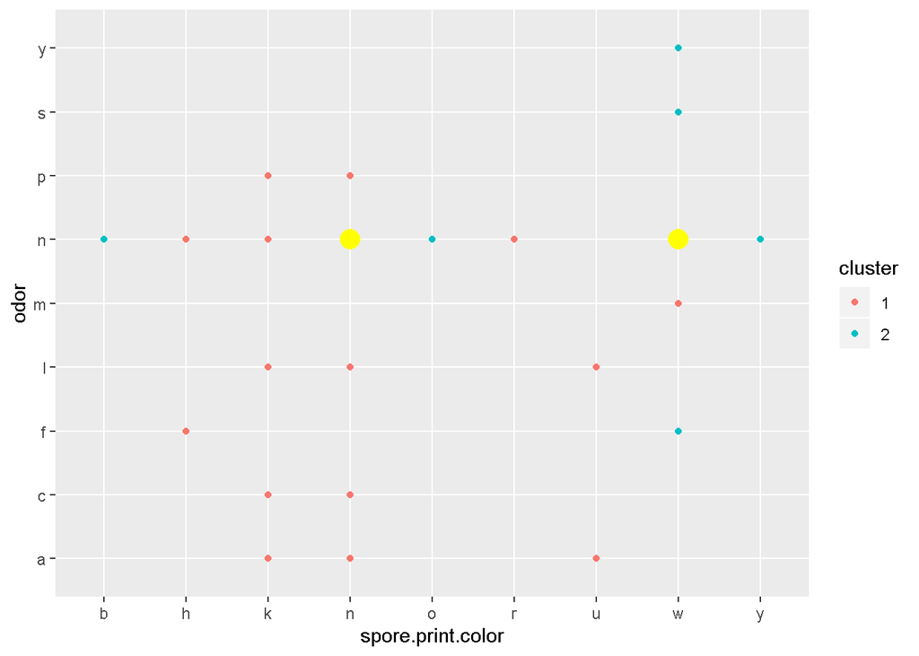

```r
#Graficamos
ggplot() + geom_point(data = nuevos.clusters,  mapping = aes(x = spore.print.color   , y = odor, color = cluster)) + geom_point(mapping = aes_string(x = modelo.kmodes$modes[, "spore.print.color"],
                                  y = modelo.kmodes$modes[, "odor"]),
                                  color = "yellow", size = 5)
```

```r
#Comparamos la clasificación por k modes vs. clasificación real
result.vs.real <- table(mushroomDf$class,modelo.kmodes$cluster)
result.vs.real
```

```
##
##        1    2
##   e 3229  979
##   p 2136 1780
```

```r
table(mushroomDf$class)
```

```
##
##    e    p
## 4208 3916
```

### K prototipos

Este método es la integración de los métodos k medias y k modas, pues está construido para datasets con variables tanto categóricas como númericas.

- El algoritmo k-prototipos es más útil porque los objetos encontrados con frecuencia en bases de datos del mundo real son objetos de tipo mixto.
- La medida de **disimilitud** para este método es la siguiente:
  $$d_{3}(X,Y)=\sum_{j=1}^{p}(x_{j}-y_{j})^{2}+\lambda \sum_{j=p+1}^{m}\delta (X_{j}, Y_{j})$$
  Dónde el primer sumando es la distancia Euclideana usada para variables numéricas y el segundo sumando es la medida de disimilitud usada para variables categóricas. El peso $\lambda$ se usa para evitar favorecer cualquier tipo de atributo.
- $\lambda$ también debe especificarse de antemano como el número de clústers k.
  - Para valores mayores de λ, el impacto de las variables categóricas aumenta.
  - Para λ = 0, el impacto de las variables categóricas desaparece y solo se toman en cuenta las variables numéricas (volvemos al método de k medias).

### Algoritmo

El algoritmo itera de manera similar al algoritmo k-medias buscando minimizar la distancia whitin cluster a través de la media para variables numéricas y la moda para variables categóricas.

1. Selección aleatoria de prototipos iniciales.
2. Asignar cada observación a su prototipo más cercano de acuerdo con $d_{3}$
3. Después de que todos los objetos se han asignado a un grupo, volver a medir la disimilitud de los objetos con los prototipos actuales. Si encontramos un objeto tal que es más cercano a otro prototipo de clúster, actualizamos los prototipos de ambos clústeres.
4. Repetir 3, hasta que ningún objeto cambie su clúster.

### Implementación en R

Pimero, es necesaria la instalación del paquete de [clustMixType](https://cran.r-project.org/web/packages/clustMixType/clustMixType.pdf)

```r
install.packages("clustMixType")
```

Usaremos la función de kproto.

```r
kproto(x, k, lambda = NULL, iter.max = 100,
  nstart = 1, na.rm = TRUE, keep.data = TRUE, verbose = TRUE, ...)
```

- **x**: Data frame with both numerics and factors.
- **k**: Either the number of clusters, a vector specifying indices of initial prototypes, or a data frame of prototypes of the same columns as x.
- **lambda** : Parameter > 0 to trade off between Euclidean distance of numeric variables and simple matching coefficient between categorical variables. Also a vector of variable specific factors is possible where the order must correspond to the order of the variables in the data. In this case all variables’ distances will be multiplied by their corresponding lambda value.
- **iter.max** : Maximum number of iterations if no convergence before.
- nstart: If > 1 repetetive computations with random initializations are computed and the result with minimum tot.dist is returned.
- na.rm: A logical value indicating whether NA values should be stripped before the computation proceeds.
- keep.data: Logical whether original should be included in the returned object.
- verbose: Logical whether information about the cluster procedure should be given. Caution: If verbose=FALSE, the reduction of the number of clusters is not mentioned.

#### Ejemplo

En este ejemplo usaremos el Pokemon with stats dataset para ilustrar el funcionamiento del método de k prototipos

```r
#Cargamos las librerías y los datos
library(clustMixType)
library(ggplot2)
library(dplyr)
pokemon <- read.csv("C:/Users/ginat/Desktop/Pokemon.csv")
str((pokemon))
```

```
## 'data.frame':    800 obs. of  13 variables:
##  $ X.        : int  1 2 3 3 4 5 6 6 6 7 ...
##  $ Name      : Factor w/ 800 levels "Abomasnow","AbomasnowMega Abomasnow",..: 81 330 746 747 103 104 100 101 102 666 ...
##  $ Type.1    : Factor w/ 18 levels "Bug","Dark","Dragon",..: 10 10 10 10 7 7 7 7 7 18 ...
##  $ Type.2    : Factor w/ 19 levels "","Bug","Dark",..: 15 15 15 15 1 1 9 4 9 1 ...
##  $ Total     : int  318 405 525 625 309 405 534 634 634 314 ...
##  $ HP        : int  45 60 80 80 39 58 78 78 78 44 ...
##  $ Attack    : int  49 62 82 100 52 64 84 130 104 48 ...
##  $ Defense   : int  49 63 83 123 43 58 78 111 78 65 ...
##  $ Sp..Atk   : int  65 80 100 122 60 80 109 130 159 50 ...
##  $ Sp..Def   : int  65 80 100 120 50 65 85 85 115 64 ...
##  $ Speed     : int  45 60 80 80 65 80 100 100 100 43 ...
##  $ Generation: int  1 1 1 1 1 1 1 1 1 1 ...
##  $ Legendary : Factor w/ 2 levels "False","True": 1 1 1 1 1 1 1 1 1 1 ...
```

En este caso no tenemos idea de cual es el valor óptimo para k entonces hacemos un *elbow plot* para darnos una idea

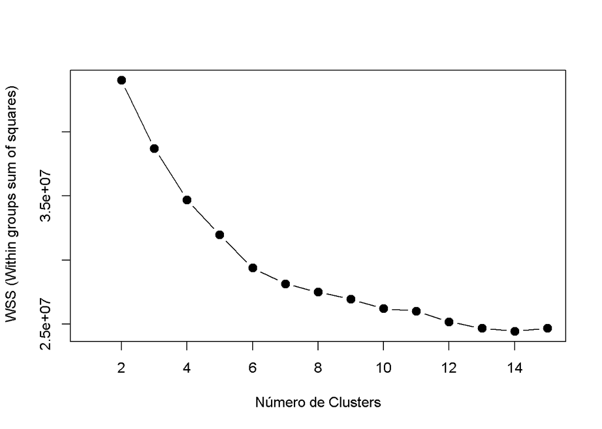

```r
# Buscamos el número óptimo de clústers
wss<-vector()
for (i in 2:15){ wss[i] <- sum(kproto(pokemon, i)$withinss)}
par(mfrow=c(1,1))
plot(1:15, wss, type="b", xlab="Número de Clusters",
     ylab=" WSS (Within groups sum of squares)",
     pch=20, cex=2)
```

Creamos el modelo de k prototipos usando k = 4

```r
modelo.kprot4 <- kproto(pokemon, 4, 10)
```

```
## # NAs in variables:
##         X.       Name     Type.1     Type.2      Total         HP     Attack
##          0          0          0          0          0          0          0
##    Defense    Sp..Atk    Sp..Def      Speed Generation  Legendary
##          0          0          0          0          0          0
## 0 observation(s) with NAs.
```

```r
nuevos.clust4 <- mutate(pokemon, cluster = as.factor(modelo.kprot4$cluster))
head(nuevos.clust4)
```

```
##   X.                  Name Type.1 Type.2 Total HP Attack Defense Sp..Atk
## 1  1             Bulbasaur  Grass Poison   318 45     49      49      65
## 2  2               Ivysaur  Grass Poison   405 60     62      63      80
## 3  3              Venusaur  Grass Poison   525 80     82      83     100
## 4  3 VenusaurMega Venusaur  Grass Poison   625 80    100     123     122
## 5  4            Charmander   Fire          309 39     52      43      60
## 6  5            Charmeleon   Fire          405 58     64      58      80
##   Sp..Def Speed Generation Legendary cluster
## 1      65    45          1     False       3
## 2      80    60          1     False       3
## 3     100    80          1     False       3
## 4     120    80          1     False       3
## 5      50    65          1     False       3
## 6      65    80          1     False       3
```

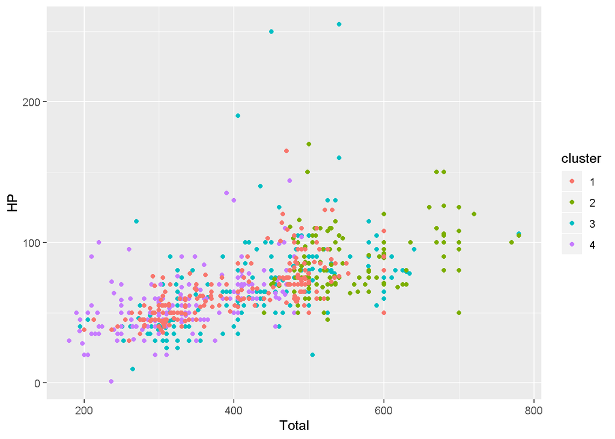

```r
#Graficamos
ggplot() + geom_point(data = nuevos.clust4,  mapping = aes(x = Total   , y = HP, color = cluster))
```

```r
#WSS
WSS4<-modelo.kprot4$tot.withinss
WSS4
```

```
## [1] 15138317
```

Creamos el modelo de k prototipos usando k = 5

```r
modelo.kprot5 <- kproto(pokemon, 5, 10)
```

```
## # NAs in variables:
##         X.       Name     Type.1     Type.2      Total         HP     Attack
##          0          0          0          0          0          0          0
##    Defense    Sp..Atk    Sp..Def      Speed Generation  Legendary
##          0          0          0          0          0          0
## 0 observation(s) with NAs.
```

```r
nuevos.clust5 <- mutate(pokemon, cluster = as.factor(modelo.kprot5$cluster))
head(nuevos.clust5)
```

```
##   X.                  Name Type.1 Type.2 Total HP Attack Defense Sp..Atk
## 1  1             Bulbasaur  Grass Poison   318 45     49      49      65
## 2  2               Ivysaur  Grass Poison   405 60     62      63      80
## 3  3              Venusaur  Grass Poison   525 80     82      83     100
## 4  3 VenusaurMega Venusaur  Grass Poison   625 80    100     123     122
## 5  4            Charmander   Fire          309 39     52      43      60
## 6  5            Charmeleon   Fire          405 58     64      58      80
##   Sp..Def Speed Generation Legendary cluster
## 1      65    45          1     False       2
## 2      80    60          1     False       2
## 3     100    80          1     False       4
## 4     120    80          1     False       4
## 5      50    65          1     False       2
## 6      65    80          1     False       2
```

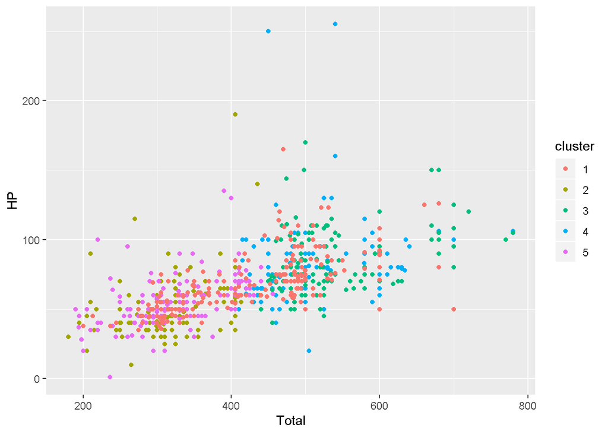

```r
#Graficamos
ggplot() + geom_point(data = nuevos.clust5,  mapping = aes(x = Total   , y = HP, color = cluster))
```

```r
#WSS
WSS5<-modelo.kprot5$tot.withinss
WSS5
```

```
## [1] 12406782
```

Creamos el modelo de k prototipos usando k = 6

```r
modelo.kprot6<- kproto(pokemon, 6, 10)
```

```
## # NAs in variables:
##         X.       Name     Type.1     Type.2      Total         HP     Attack
##          0          0          0          0          0          0          0
##    Defense    Sp..Atk    Sp..Def      Speed Generation  Legendary
##          0          0          0          0          0          0
## 0 observation(s) with NAs.
```

```r
nuevos.clust6 <- mutate(pokemon, cluster = as.factor(modelo.kprot6$cluster))
head(nuevos.clust6)
```

```
##   X.                  Name Type.1 Type.2 Total HP Attack Defense Sp..Atk
## 1  1             Bulbasaur  Grass Poison   318 45     49      49      65
## 2  2               Ivysaur  Grass Poison   405 60     62      63      80
## 3  3              Venusaur  Grass Poison   525 80     82      83     100
## 4  3 VenusaurMega Venusaur  Grass Poison   625 80    100     123     122
## 5  4            Charmander   Fire          309 39     52      43      60
## 6  5            Charmeleon   Fire          405 58     64      58      80
##   Sp..Def Speed Generation Legendary cluster
## 1      65    45          1     False       5
## 2      80    60          1     False       5
## 3     100    80          1     False       5
## 4     120    80          1     False       5
## 5      50    65          1     False       5
## 6      65    80          1     False       5
```

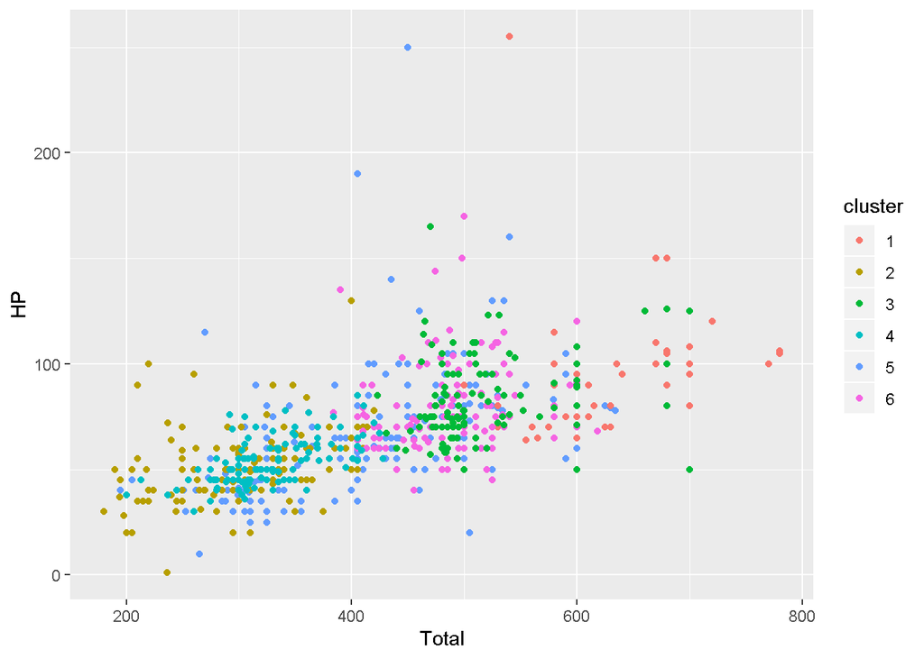

```r
#Graficamos
ggplot() + geom_point(data = nuevos.clust6,  mapping = aes(x = Total   , y = HP, color = cluster))
```

```r
#WSS
WSS6<-modelo.kprot6$tot.withinss
WSS6
```

```
## [1] 10866348
```

Creamos el modelo de k prototipos usando k = 7

```r
modelo.kprot7 <- kproto(pokemon, 7, 10)
```

```
## # NAs in variables:
##         X.       Name     Type.1     Type.2      Total         HP     Attack
##          0          0          0          0          0          0          0
##    Defense    Sp..Atk    Sp..Def      Speed Generation  Legendary
##          0          0          0          0          0          0
## 0 observation(s) with NAs.
```

```r
nuevos.clust7 <- mutate(pokemon, cluster = as.factor(modelo.kprot7$cluster))
head(nuevos.clust7)
```

```
##   X.                  Name Type.1 Type.2 Total HP Attack Defense Sp..Atk
## 1  1             Bulbasaur  Grass Poison   318 45     49      49      65
## 2  2               Ivysaur  Grass Poison   405 60     62      63      80
## 3  3              Venusaur  Grass Poison   525 80     82      83     100
## 4  3 VenusaurMega Venusaur  Grass Poison   625 80    100     123     122
## 5  4            Charmander   Fire          309 39     52      43      60
## 6  5            Charmeleon   Fire          405 58     64      58      80
##   Sp..Def Speed Generation Legendary cluster
## 1      65    45          1     False       1
## 2      80    60          1     False       1
## 3     100    80          1     False       7
## 4     120    80          1     False       7
## 5      50    65          1     False       1
## 6      65    80          1     False       1
```

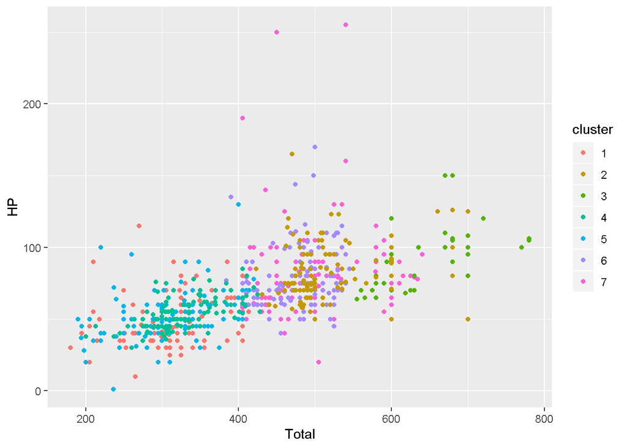

```r
#Graficamos
ggplot() + geom_point(data = nuevos.clust7,  mapping = aes(x = Total   , y = HP, color = cluster))
```

```r
#WSS
WSS7<-modelo.kprot7$tot.withinss
WSS7
```

```
## [1] 8902119
```

Gráficamente no es fácil distinguir cuál es el valor óptimo de k para este ejmplo, entonces veamos la WSS de cada modelo

```r
WSS<-c(WSS4, WSS5, WSS6, WSS7)
WSS
```

```
## [1] 15138317 12406782 10866348  8902119
```

```r
min(WSS4, WSS5, WSS6, WSS7)
```

```
## [1] 8902119
```

Como podemos observar el modelo con **k = 7** tiene la menor Total Within Sum of Squares, por lo que es el mejor ajuste para estos datos.